# IATI as network data: results

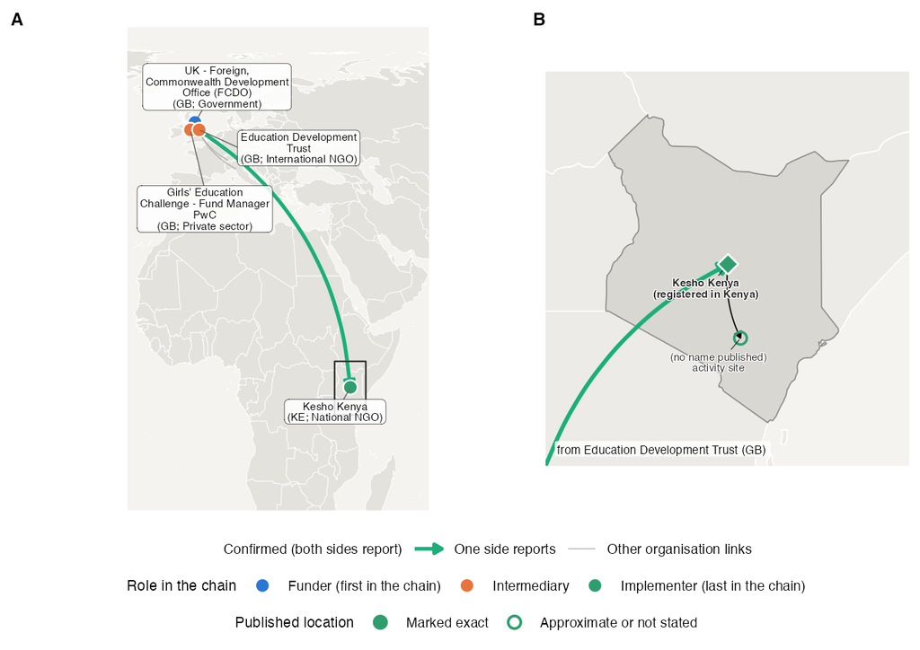

**Figure 25.** Example chain map (showcase rank 4 of 5; selection rule in Annex A.8). A chain from UK - Foreign, Commonwealth Development Office (FCDO) to Kesho Kenya, 3 steps (0 confirmed by both sides), years 2017 to 2023. Relates to the place level of Table 4 (Section 7.4) and the chain level (Section 6). A: organizations placed by country of registration, each labeled with its full name, country of registration and IATI organization type; color shows the organization’s role, taken from its position in the chain (first: funder; last: implementer; between: intermediary), not from an IATI field. Arrows: the chain’s activity links, colored by evidence as in the chain diagrams (blue: confirmed by both sides; green: reported by one side); gray: other organization links of the same organizations (up to 15 each). Box: the end country. B: the end country (equal-area projection centred on it); the implementer (diamond) is drawn at the country’s label point, not at a published location, with arrows to the usable points its end activity publishes (1), each labeled with its published name and location reach (activity site, or where beneficiaries live); filled if marked exact, hollow if approximate or not stated. Equal Earth projection (A). Unit: organizations; activity links; location points.

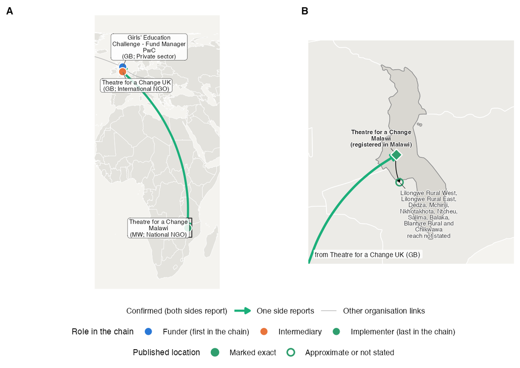

**Figure 26.** Example chain map (showcase rank 5 of 5; selection rule in Annex A.8). A chain from Girls’ Education Challenge - Fund Manager PwC to Theatre for a Change Malawi, 2 steps (0 confirmed by both sides), years 2013 to 2017. Relates to the place level of Table 4 (Section 7.4) and the chain level (Section 6). A: organizations placed by country of registration, each labeled with its full name, country of registration and IATI organization type; color shows the organization’s role, taken from its position in the chain (first: funder; last: implementer; between: intermediary), not from an IATI field. Arrows: the chain’s activity links, colored by evidence as in the chain diagrams (blue: confirmed by both sides; green: reported by one side); gray: other organization links of the same organizations (up to 15 each). Box: the end country. B: the end country (equal-area projection centred on it); the implementer (diamond) is drawn at the country’s label point, not at a published location, with arrows to the usable points its end activity publishes (1), each labeled with its published name and location reach (activity site, or where beneficiaries live); filled if marked exact, hollow if approximate or not stated. Equal Earth projection (A). Unit: organizations; activity links; location points.

**Interactive**

Every candidate chain whose end activity has a usable point (28 chains). Click a point for the chain; larger points are the examples. The map uses the Web Mercator projection, which enlarges areas far from the equator; use it to explore, not to compare sizes. Country borders are Natural Earth, built into the report, so it works offline.

[interactive chart not shown]

**All candidates**

| rank | counterexample | route | steps | confirmed | end_type | usable_points | years |
| --- | --- | --- | --- | --- | --- | --- | --- |
| 1 | False | UK - Foreign, Commonwealth Development Office (FCDO) &gt; MannionDanniels &gt; Orbis Charitable Trust &gt; Orbis International &gt; Orbis Ethiopia | 4 | 3 | National NGO | 3 | 2016–2023 |
| 2 | False | UK - Foreign, Commonwealth Development Office (FCDO) &gt; MannionDanniels &gt; EMMS International &gt; David Gordon Memorial Hospital | 3 | 2 | National NGO | 1 | 2018–2022 |
| 3 | False | Ministry of Foreign Affairs of the Netherlands &gt; Womankind Worldwide &gt; Siiqqee Women's Development Association | 2 | 1 | National NGO | 1 | 2021–2026 |
| 4 | False | UK - Foreign, Commonwealth Development Office (FCDO) &gt; Girls' Education Challenge - Fund Manager PwC &gt; Education Development Trust &gt; Kesho Kenya | 3 | 0 | National NGO | 1 | 2017–2023 |
| 5 | False | Girls' Education Challenge - Fund Manager PwC &gt; Theatre for a Change UK &gt; Theatre for a Change Malawi | 2 | 0 | National NGO | 1 | 2013–2017 |
| 6 | False | Ministry of Foreign Affairs of the Netherlands &gt; SNV Netherlands Development Organisation &gt; Join For Water (Protos) | 2 | 0 | National NGO | 4 | 2016–2021 |
| 7 | False | UK - Foreign, Commonwealth Development Office (FCDO) &gt; MannionDanniels &gt; PROTECTING FAMILIES AGAINST HIV/AIDS (PREFA) | 2 | 0 | National NGO | 1 | 2016–2023 |
| 8 | False | UK - Foreign, Commonwealth Development Office (FCDO) &gt; Guttmacher Institute &gt; CREHPA | 2 | 0 | National NGO | 1 | 2016–2022 |
| 9 | False | Ministry of Foreign Affairs of the Netherlands &gt; IRC-UK &gt; International Rescue Committee Inc. &gt; ZOA | 3 | 2 | International NGO | 1 | 2017–2023 |
| 10 | False | Ministry of Foreign Affairs of the Netherlands &gt; Stichting Beheer Subsidiegelden DRA &gt; Cordaid &gt; Stichting Vluchteling | 3 | 2 | International NGO | 1 | 2018–2021 |

[output cut: 19 more lines]

**Coverage**

Published locations, by the point check (unit: locations).

| Status | Locations |
| --- | --- |
| valid | 549,961 |
| no point | 97,847 |
| unreadable | 1,479 |
| out of range or 0,0 | 291 |
| valid, inside a recipient country | 486,303 |
| valid, outside all recipient countries | 17,289 |
| valid, coded as a whole country | 25,195 |
| usable | 483,024 |

### Method: locations, the point check and the choice of examples

**Locations.** Stage 6 reads the `<location>` elements of each activity directly from the XML of the bulk copy (`locations.parquet`), for the copy of the activity kept in stage 2. Version 2 gives a point as `<point><pos>latitude longitude</pos></point>`; version 1 as `<coordinates latitude longitude>`. Both are read. `<location>` elements inside results and indicators only refer back to these, and are not counted.

**Valid and usable points.** A point is *valid* if latitude and longitude can be read, lie in range and are not 0,0, a common placeholder. Of the valid points, 486,303 lie inside one of their activity’s recipient countries and 17,289 lie outside all of them. The check uses the Natural Earth borders of the maps, widened by about 25 km for coasts and borders (`POINT_COUNTRY_TOLERANCE_DEG`). 25,195 points are coded as a whole country (GeoNames feature `PCL…`). A point is *usable* for the examples if it is valid, inside a recipient country, and not country-level.

**Where organizations are drawn.** IATI gives no address for organizations. Each organization is drawn at its *country of registration*: the country prefix of its identifier (`GB-CHC-…` → United Kingdom). Identifiers without a country prefix (`XM-`, `XI-`, `XR-` and legacy codes) are drawn at the organization’s headquarters country in the IATI Registry, if it publishes. This covers both governments that publish under their OECD-DAC donor code (`XM-DAC-` below 900, for example `XM-DAC-7`, the Netherlands), which count as national, and international bodies (other `XM-`, `XI-` and `XR-` identifiers). Organizations in the same country are spread on a small circle. This is where an organization is registered, not where it works. Only the end activity’s points (panel B) show where work happens.

**Choice of examples.** Chains whose end activity has a usable point are ranked:

1. the end publisher is a local organization (local government, national, regional or partner-country NGO, private sector in the recipient country);
2. more steps confirmed by both sides;
3. more steps;
4. more activities on the chain with usable points.

To show different routes, only the best-ranked chain is kept for each organization path, each end publisher, and each route before the end publisher. A chain that ends at an organization it already passed through is left out. The first 5 are shown. The **counter-example** is the best-ranked chain by the same rules whose end activity has *no* usable point. All candidates are in the tab “All candidates” and in `geo_chains.csv`.

## 11. Flows between countries

Section 9 maps traceability where the money goes, and section 10 follows single chains. This section asks a simpler question about the whole network: **where are funders registered, and in which countries do the activities they are linked to work?** It counts the 13,024 links in the network (unit: links; plausible links between activities of different organizations, all years).

These are links, not money: a link can rest on one transaction or many, and values are not added across currencies.

**Map with routes**

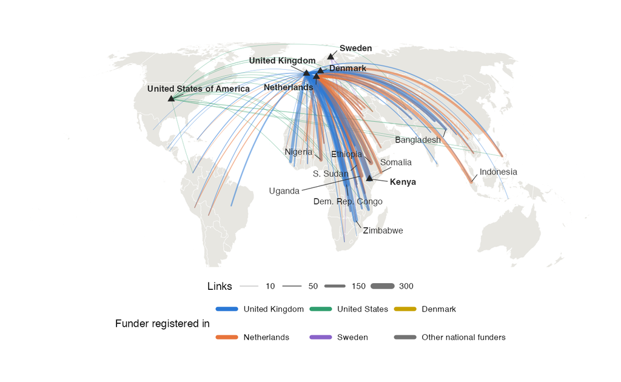

**Figure 16.** Figure 16. Cross-border network links from national funders, by the funder’s country of registration and the recipient country. National funders only (funding organizations registered in a country; international bodies are counted but not drawn), receiving activities in one recipient country, all years. Links, not money: each link is one activity link between a funder’s activity and a receiving activity (Table 4, place level; Section 7.3). Drawn: every country pair with 10 or more links (128 pairs, 7,382 of the 8,540 cross-border links in 565 pairs). Lines follow the shortest path between the two countries; the 3 routes whose shortest path crosses the date line at the map edge are drawn as straight lines across the map. Line width: links; color: funder country (the same in Figures 17 and 18). Triangles and bold labels: funder countries; plain labels: the 10 recipient countries with most links (a country that is both, such as Kenya, is labeled in bold). Equal Earth projection. Unit: links.

**Small maps**

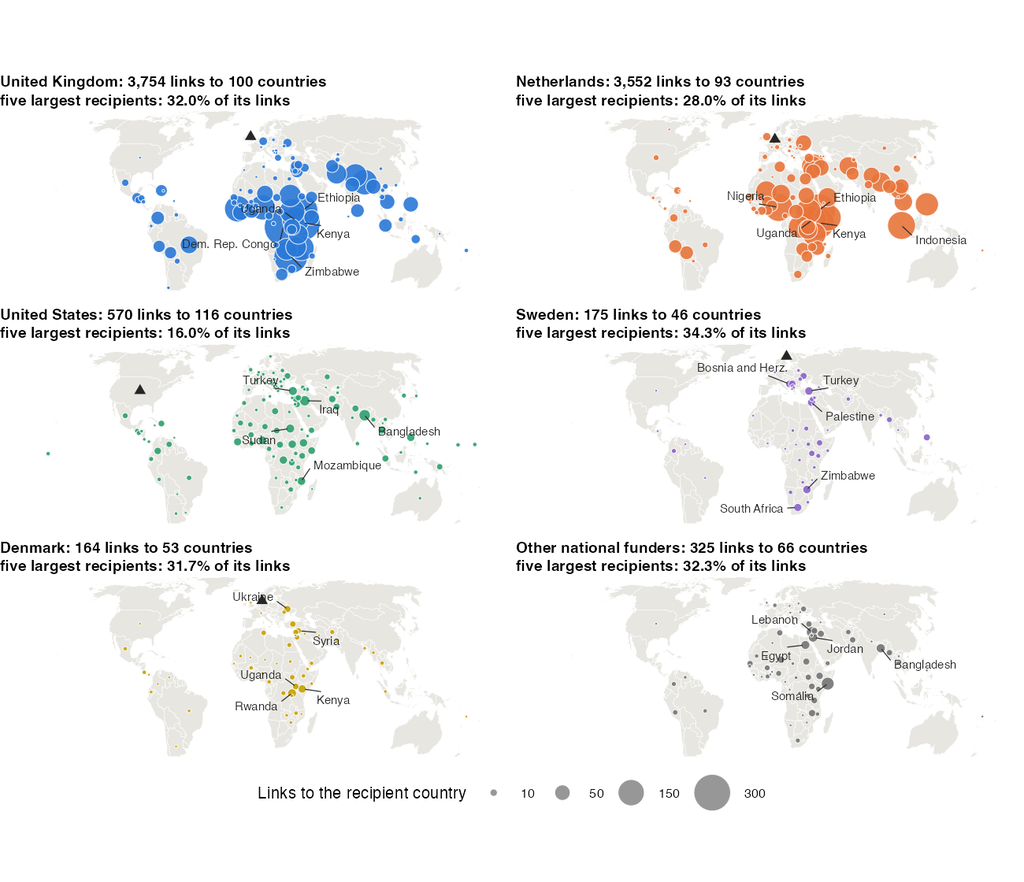

**Figure 17.** Figure 17. Cross-border network links by funder country. National funders only (funding organizations registered in a country; international bodies are counted but not drawn), receiving activities in one recipient country, all years. Links, not money: each link is one activity link between a funder’s activity and a receiving activity (Table 4, place level; Section 7.3). All 8,540 cross-border links in 565 country pairs. One map per funder country (the five with most links; other national funders together); circle area shows the number of links to each recipient country, on the same scale in every panel. Triangle: funder country. Labels: the five recipient countries with most links in each panel. Under each title: links, recipient countries, and the share of the funder’s links that go to its five largest recipient countries. Colors as in Figures 16 and 18. Equal Earth projection. Unit: links.

**By year**

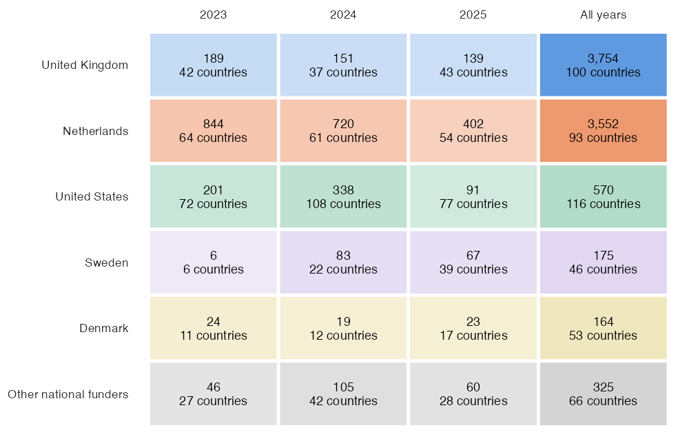

**Figure 17b.** Figure 17b. Cross-border network links by funder country and year: links (and recipient countries) with at least one transaction dated in the year; all years for comparison. National funders only (funding organizations registered in a country; international bodies are counted but not drawn), receiving activities in one recipient country, all years. Links, not money: each link is one activity link between a funder’s activity and a receiving activity (Table 4, place level; Section 7.3). A link can count in several years, so the years do not add up to all years. Color as in Figures 16 to 18; shade rises with the number of links. Unit: links.

**Ribbons**

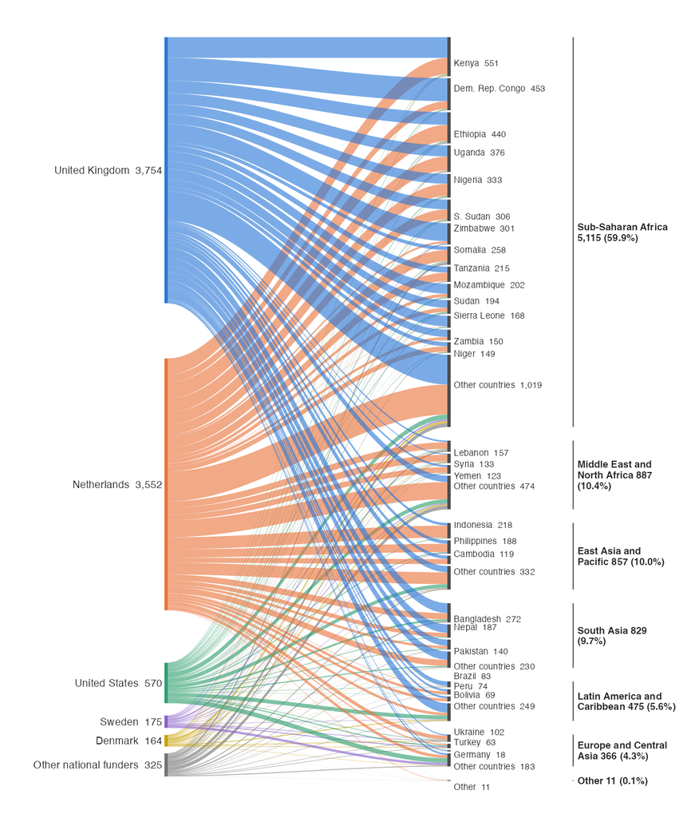

**Figure 18.** Figure 18. All cross-border network links from national funders, from the funder’s country of registration (left) to the recipient country (middle) and region (right). National funders only (funding organizations registered in a country; international bodies are counted but not drawn), receiving activities in one recipient country, all years. Links, not money: each link is one activity link between a funder’s activity and a receiving activity (Table 4, place level; Section 7.3). 8,540 links in 565 country pairs. Ribbon width shows the number of links; numbers are links; region labels give the region’s links and its share of all cross-border links. Recipient countries: the 14 with most links in Sub-Saharan Africa and the 3 with most links in each other region; the rest are grouped by region (‘Other countries’). Regions: World Bank regions (Natural Earth). Colors as in Figures 16 and 17. Unit: links.

**Table**

| funder_country | international | recipient | links | confirmed | receiver_registered_here | domestic |
| --- | --- | --- | --- | --- | --- | --- |
| GB | False | region only | 575 | 12 | 0 | False |
| GB | False | several countries | 420 | 35 | 0 | False |
| NL | False | region only | 420 | 21 | 0 | False |
| GB | False | CD | 324 | 14 | 0 | False |
| GB | False | KE | 292 | 20 | 21 | False |
| GB | False | ZW | 253 | 3 | 2 | False |
| NL | False | NL | 241 | 21 | 240 | True |
| NL | False | several countries | 237 | 30 | 0 | False |
| NL | False | ET | 230 | 24 | 20 | False |
| NL | False | KE | 229 | 7 | 19 | False |

[output cut: 805 more lines]

**Not drawn**

Network links by what is known about each end (unit: links). Only links with a known funder country and one recipient country are drawn.

| recipient | funder country known | funder country unknown |
| --- | --- | --- |
| no country or region | 66 | 0 |
| one country | 9,443 | 1,175 |
| region only | 1,485 | 92 |
| several countries | 761 | 2 |

### Local receivers

**By country**

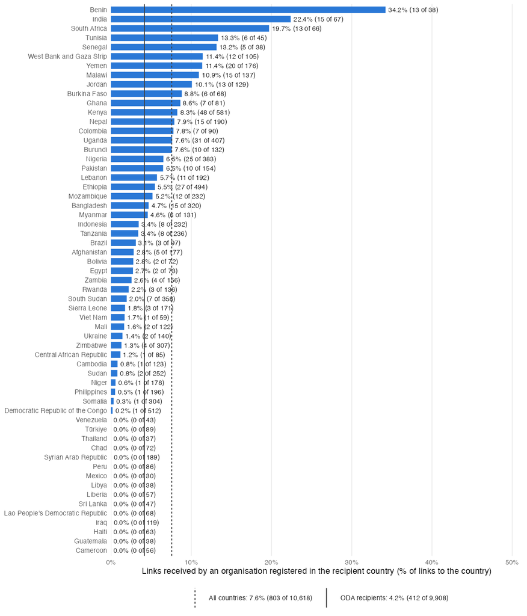

**Figure 27.** Figure 27. Share of links received by an organization registered in the recipient country (the local share of Table 4, place level, Section 7.5), all years. Links: network activity links to an activity in one recipient country, from all funders. Local: the receiving organization’s identifier places it in that country; this does not separate national affiliates of international organizations from independent local organizations. Shown: the 59 ODA recipients (DAC List of ODA Recipients, 2025 flows) with 30 or more links, sorted by share; labels: share (local links of all links). Lines: all countries, 7.6% (803 of 10,618) (including donor countries such as the Netherlands, where ‘local’ means something different); ODA recipients only, 4.2% (412 of 9,908). Unit: links.

**2025**

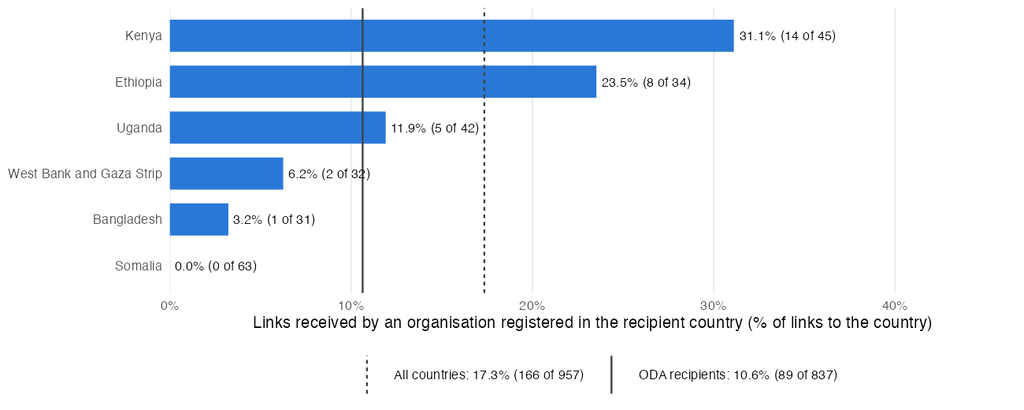

**Figure 27b.** Figure 27b. Share of links received by an organization registered in the recipient country (the local share of Table 4, place level, Section 7.5), links with a transaction dated 2025. Links: network activity links to an activity in one recipient country, from all funders. Local: the receiving organization’s identifier places it in that country; this does not separate national affiliates of international organizations from independent local organizations. Shown: the 6 ODA recipients (DAC List of ODA Recipients, 2025 flows) with 30 or more links, sorted by share; labels: share (local links of all links). Lines: all countries, 17.3% (166 of 957) (including donor countries such as the Netherlands, where ‘local’ means something different); ODA recipients only, 10.6% (89 of 837). Unit: links. Only a few countries reach 30 links in one year.

**Steps to local organizations**

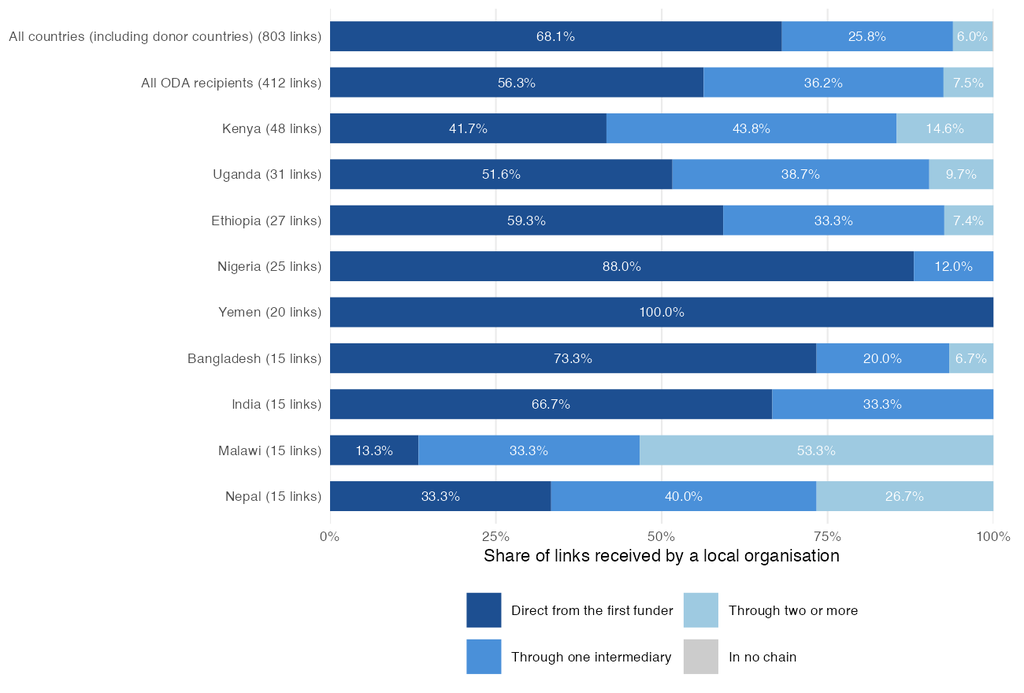

**Figure 28.** How many steps funding takes to reach local organizations (Section 7.5; the local share of Table 4, place level, by chain step, chain level). For every network link received by an organization registered in the recipient country (as in Figure 27), the fewest steps from a chain origin: direct from the first funder (1 step), through one intermediary (2 steps), or through two or more. This follows the Grand Bargain distinction between funding that reaches local and national actors directly or through one intermediary (IASC, 2018). ‘Direct’ means direct from the first funder visible in IATI: that funder may itself have been funded by an organization that does not publish. Bars: all countries (including donor countries, where ‘local’ means something different), all ODA recipients (DAC list, 2025 flows), and the 9 ODA recipients with 15 or more local links, ordered by their number of local links. The threshold was lowered from 30 to 15 so that more countries can be compared (at 30 only 2 countries qualify); with 15 to 30 links, one link moves a country’s shares by about 3 to 7 percentage points, so differences between countries are indicative only. Each bar splits that group’s local links by the fewest steps from the first funder, so the segments add up to 100%. By origin funder country: local_by_steps.csv. All years. Unit: links.

## 12. Exclusions and data issues

Known exclusions and data issues

| Issue | Count | Unit | Treatment |
| --- | --- | --- | --- |
| Datasets in the index with no file in the copy | 747 | datasets | Excluded; listed in datasets_missing.csv |
| Files that cannot be parsed | 10 | files | Excluded |
| Activity copies removed as duplicates | 5,553 | activity copies | One copy kept per activity |
| Exact duplicate transactions | 225,206 | transactions | Flagged; left out (D1) |
| Internal flows (counterpart is the publisher itself) | 2,023,166 | transactions | Left out of link indicators |
| Organisation ID written in the activity-ID field | 343,092 | transactions | Reported as x1b; left out of x1 |
| Version 1 or named type codes recoded | 31,565 | transactions | Recoded |
| Invalid type codes | 77 | transactions | Kept; no direction |

## 13. Citation information

Please cite the pipeline and the data copy it was run on:

> Bernhard, K.P. (2026). *IATI as network data: traceability pipeline*. Code repository: https://github.com/iatireport/iati-network-traceability. Results from the IATI Bulk Data Service copy of 2026-10-30.

For the key headline results, cite the final report.

## 14. Software

R and package versions used for this report

| package | version |
| --- | --- |
| R | 4.3.2 |
| tidyverse | 2.0.0 |
| arrow | 20.0.0.2 |
| jsonlite | 1.8.8 |
| igraph | 2.0.2 |
| ggraph | 2.2.1 |
| knitr | 1.45 |
| sf | 1.0.16 |
| rnaturalearth | 1.1.0 |
| patchwork | 1.3.1 |
| ggrepel | 0.9.6 |
| leaflet | 2.2.2 |
| plotly | 4.11.0 |
| DT | 0.33 |
| visNetwork | 2.1.2 |
| viridisLite | 0.4.2 |